# PLOTLY TUTORIAL-2

**In this notebook, my aim is to investigate flight delays and cancellation reasons in several aspects while generating a comprehensive tutorial for PLOTLY enthusiasts.**

**PLOTLY TUTORIAL - 1 (Kaggle ML and Data Science Survey): https://www.kaggle.com/hakkisimsek/plotly-tutorial-1**

**PLOTLY TUTORIAL - 3 (S&P 500 Stock Data): https://www.kaggle.com/hakkisimsek/plotly-tutorial-3**

**PLOTLY TUTORIAL - 4 (Google Store Customer Data): https://www.kaggle.com/hakkisimsek/plotly-tutorial-4**

**PLOTLY TUTORIAL - 5 (Kaggle Survey 2018): https://www.kaggle.com/hakkisimsek/plotly-tutorial-5**

**Before we start , it would be good to know the impact of flight delays on airlines & customers.**

"Delayed aircraft are estimated to have cost the airlines several billion dollars in additional expense. Delays also drive the need for extra gates and ground personnel and impose costs on airline customers (including shippers) in the form of lost productivity, wages and goodwill.

Assuming 49 dollars per hour as the average value of a passenger’s time, 2017 delays are estimated to have cost air travelers billions of dollars. FAA/Nextor estimated the annual costs of delays (direct cost to airlines and passengers, lost demand, and indirect costs) in 2017 to be $26.6 billion."

source: http://airlines.org/dataset/per-minute-cost-of-delays-to-u-s-airlines/

[figure not shown]

source: http://www.timqian.com/star-history/#bokeh/bokeh&plotly/dash

```python
import pandas as pd
import numpy as np
import matplotlib.pyplot as plt
import seaborn as sns

import plotly.offline as py
import plotly.figure_factory as ff
py.init_notebook_mode(connected=True)
import plotly.graph_objs as go
from plotly import tools

import warnings
warnings.filterwarnings('ignore')

df = pd.read_csv('./archive/flights.csv', low_memory=False)
df.head(2).T
```

|  | 0 | 1 |
| --- | --- | --- |
| YEAR | 2015 | 2015 |
| MONTH | 1 | 1 |
| DAY | 1 | 1 |
| DAY_OF_WEEK | 4 | 4 |
| AIRLINE | AS | AA |
| FLIGHT_NUMBER | 98 | 2336 |
| TAIL_NUMBER | N407AS | N3KUAA |
| ORIGIN_AIRPORT | ANC | LAX |
| DESTINATION_AIRPORT | SEA | PBI |
| SCHEDULED_DEPARTURE | 5 | 10 |
| DEPARTURE_TIME | 2354.0 | 2.0 |
| DEPARTURE_DELAY | -11.0 | -8.0 |
| TAXI_OUT | 21.0 | 12.0 |
| WHEELS_OFF | 15.0 | 14.0 |
| SCHEDULED_TIME | 205.0 | 280.0 |
| ELAPSED_TIME | 194.0 | 279.0 |
| AIR_TIME | 169.0 | 263.0 |
| DISTANCE | 1448 | 2330 |
| WHEELS_ON | 404.0 | 737.0 |
| TAXI_IN | 4.0 | 4.0 |
| SCHEDULED_ARRIVAL | 430 | 750 |
| ARRIVAL_TIME | 408.0 | 741.0 |
| ARRIVAL_DELAY | -22.0 | -9.0 |
| DIVERTED | 0 | 0 |
| CANCELLED | 0 | 0 |
| CANCELLATION_REASON | NaN | NaN |
| AIR_SYSTEM_DELAY | NaN | NaN |
| SECURITY_DELAY | NaN | NaN |
| AIRLINE_DELAY | NaN | NaN |
| LATE_AIRCRAFT_DELAY | NaN | NaN |
| WEATHER_DELAY | NaN | NaN |

**I write equations of unclear variables as below.**

- taxi_out = wheels_off - departure_time
- taxi_in = arrival_time - wheels_on
- air_time = wheels_on - wheels_off
- elapsed_time =air_time + taxi_in + taxi_out

**First of all control data types & missing records and their percentages in columns.**

```python
df.info()
```

```
<class 'pandas.core.frame.DataFrame'>
RangeIndex: 5819079 entries, 0 to 5819078
Data columns (total 31 columns):
 #   Column               Dtype
---  ------               -----
 0   YEAR                 int64
 1   MONTH                int64
 2   DAY                  int64
 3   DAY_OF_WEEK          int64
 4   AIRLINE              object
 5   FLIGHT_NUMBER        int64
 6   TAIL_NUMBER          object
 7   ORIGIN_AIRPORT       object
 8   DESTINATION_AIRPORT  object
 9   SCHEDULED_DEPARTURE  int64
```

[output cut: 23 more lines]

```python
pd.concat([df.isnull().sum(), 100 * df.isnull().sum()/len(df)],
              axis=1).rename(columns={0:'Missing Records', 1:'Percentage (%)'})
```

|  | Missing Records | Percentage (%) |
| --- | --- | --- |
| YEAR | 0 | 0.000000 |
| MONTH | 0 | 0.000000 |
| DAY | 0 | 0.000000 |
| DAY_OF_WEEK | 0 | 0.000000 |
| AIRLINE | 0 | 0.000000 |
| FLIGHT_NUMBER | 0 | 0.000000 |
| TAIL_NUMBER | 14721 | 0.252978 |
| ORIGIN_AIRPORT | 0 | 0.000000 |
| DESTINATION_AIRPORT | 0 | 0.000000 |
| SCHEDULED_DEPARTURE | 0 | 0.000000 |
| DEPARTURE_TIME | 86153 | 1.480526 |
| DEPARTURE_DELAY | 86153 | 1.480526 |
| TAXI_OUT | 89047 | 1.530259 |
| WHEELS_OFF | 89047 | 1.530259 |
| SCHEDULED_TIME | 6 | 0.000103 |
| ELAPSED_TIME | 105071 | 1.805629 |
| AIR_TIME | 105071 | 1.805629 |
| DISTANCE | 0 | 0.000000 |
| WHEELS_ON | 92513 | 1.589822 |
| TAXI_IN | 92513 | 1.589822 |
| SCHEDULED_ARRIVAL | 0 | 0.000000 |
| ARRIVAL_TIME | 92513 | 1.589822 |
| ARRIVAL_DELAY | 105071 | 1.805629 |
| DIVERTED | 0 | 0.000000 |
| CANCELLED | 0 | 0.000000 |
| CANCELLATION_REASON | 5729195 | 98.455357 |
| AIR_SYSTEM_DELAY | 4755640 | 81.724960 |
| SECURITY_DELAY | 4755640 | 81.724960 |
| AIRLINE_DELAY | 4755640 | 81.724960 |
| LATE_AIRCRAFT_DELAY | 4755640 | 81.724960 |
| WEATHER_DELAY | 4755640 | 81.724960 |

**Follow same steps for a new data-set.**

```python
airlines = pd.read_csv('./archive/airlines.csv')
```

**We should merge the first and second data sets because there are detailed airline info in the latter.**

```python
df = pd.merge(df,airlines, left_on='AIRLINE', right_on = 'IATA_CODE')
df.insert(loc=5, column='AIRLINE', value=df.AIRLINE_y)
df = df.drop(['AIRLINE_y','IATA_CODE'], axis=1)
```

**Again follow the same procedure for the airport data set that contains airport & city info.**

```python
airport = pd.read_csv('./archive/airports.csv')
df = pd.merge(df,airport[['IATA_CODE','AIRPORT','CITY']], left_on='ORIGIN_AIRPORT', right_on = 'IATA_CODE')
df = df.drop(['IATA_CODE'], axis=1)
df = pd.merge(df,airport[['IATA_CODE','AIRPORT','CITY']], left_on='DESTINATION_AIRPORT', right_on = 'IATA_CODE')
df = df.drop(['IATA_CODE'], axis=1)
```

**What would you like to learn first? It would be great to visualize categoric and temporal variables quickly to see boundaries of the data set.**

**Then, we could analyze our dependent variables (arrival delay & departure delay) more detailly.**

> **Logic behind the Plotly visuals is simple. Put everything related to data in trace and everything not related to data (like title or axis rotations) in layout and finally put both trace and layout in a figure. That's all!**

```python
dff = df['AIRPORT_x'].value_counts()[:10]
label = dff.index
size = dff.values

colors = ['skyblue', '#FEBFB3', '#96D38C', '#D0F9B1', 'gold', 'orange', 'lightgrey',
          'lightblue','lightgreen','aqua']
trace = go.Pie(labels=label, values=size, marker=dict(colors=colors),hole = .2)

data = [trace]
layout = go.Layout(
    title='Origin Airport Distribution'
)

fig = go.Figure(data=data, layout=layout)
py.iplot(fig)
```

[interactive chart not shown]

```python
dff = df.CITY_x.value_counts()[:10]

trace = go.Bar(
    x=dff.index,
    y=dff.values,
    marker=dict(
        color = dff.values,
        colorscale='Jet',
        showscale=True
    )
)

data = [trace]
layout = go.Layout(
    title='Origin City Distribution',
    yaxis = dict(title = '# of Flights')
)

fig = go.Figure(data=data, layout=layout)
py.iplot(fig)
```

[interactive chart not shown]

```python
dff = df.AIRLINE.value_counts()[:10]

trace = go.Bar(
    x=dff.index,
    y=dff.values,
    marker=dict(
        color = dff.values,
        colorscale='Jet',
        showscale=True)
)

data = [trace]
layout = go.Layout(xaxis=dict(tickangle=15),
    title='Airline distribution',
                   yaxis = dict(title = '# of Flights'))

fig = go.Figure(data=data, layout=layout)
py.iplot(fig)
```

[interactive chart not shown]

```python
dff = df.MONTH.value_counts().to_frame().reset_index().sort_values(by='index')
dff.columns = ['month', 'flight_num']
month = {1: 'Jan', 2: 'Feb', 3: 'Mar', 4: 'Apr', 5: 'May',
            6: 'Jun', 7: 'Jul', 8: 'Aug', 9: 'Sep', 10: 'Oct', 11: 'Nov', 12: 'Dec'}
dff.month = dff.month.map(month)

trace = go.Bar(
    x=dff.month,
    y=dff.flight_num,
    marker=dict(
        color = dff.flight_num,
        colorscale='Reds',
        showscale=True)
)

data = [trace]
layout = go.Layout(
    title='# of Flights (monthly)',
    yaxis = dict(title = '# of Flights'
                                                )
)

fig = go.Figure(data=data, layout=layout)
py.iplot(fig)
```

[interactive chart not shown]

```python
df['dep_delay'] = np.where(df.DEPARTURE_DELAY>0,1,0)
df['arr_delay'] = np.where(df.ARRIVAL_DELAY>0,1,0)
dff = df.groupby('MONTH').dep_delay.mean().round(2)

dff.index = dff.index.map(month)
trace1 = go.Bar(
    x=dff.index,
    y=dff.values,
    name = 'Departure_delay',
    marker = dict(
        color = 'aqua'
    )
)

dff = df.groupby('MONTH').arr_delay.mean().round(2)
dff.index = dff.index.map(month)

trace2 = go.Bar(
    x=dff.index,
    y=dff.values,
    name='Arrival_delay',
    marker=dict(
        color = 'red'
    )
)

data = [trace1,trace2]
layout = go.Layout(
    title='% Delay (Months)',
    yaxis = dict(title = '%')
)

fig = go.Figure(data=data, layout=layout)
py.iplot(fig)
```

[interactive chart not shown]

```python
dayOfWeek={1:'Monday', 2:'Tuesday', 3:'Wednesday', 4:'Thursday', 5:'Friday',
                                           6:'Saturday', 7:'Sunday'}
dff = df.DAY_OF_WEEK.value_counts()
dff = dff.to_frame().sort_index()
dff.index = dff.index.map(dayOfWeek)

trace1 = go.Bar(
    x=dff.index,
    y=dff.DAY_OF_WEEK,
    name = 'Weather',
    marker=dict(
        color = dff.DAY_OF_WEEK,
        colorscale='Jet',
        showscale=True
    )
)

data = [trace1]
layout = go.Layout(
    title='# of Flights (Day of Week)',
    yaxis = dict(title = '# of Flights'
                                                    )
)

fig = go.Figure(data=data, layout=layout)
py.iplot(fig)
```

[interactive chart not shown]

**Air traffic by cities from both seaborn & plotly perspectives.**

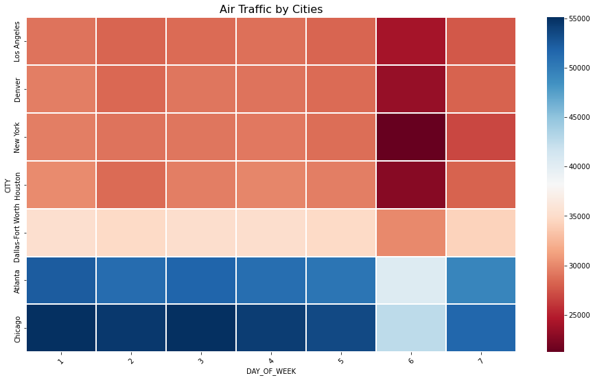

```python
flight_volume = df.pivot_table(index="CITY_x",columns="DAY_OF_WEEK",
                               values="DAY",aggfunc=lambda x:x.count())
fv = flight_volume.sort_values(by=1, ascending=False)[:7]
fv = fv.iloc[::-1]

fig = plt.figure(figsize=(16,9))
sns.heatmap(fv, cmap='RdBu',linecolor="w", linewidths=2)

plt.title('Air Traffic by Cities',size=16)
plt.ylabel('CITY')
plt.xticks(rotation=45)
plt.show()
```

```python
flight_volume = df.pivot_table(index="CITY_x",columns="DAY_OF_WEEK",
                               values="DAY",aggfunc=lambda x:x.count())
fv = flight_volume.sort_values(by=1, ascending=False)[:8]
fv.index = np.where(fv.index=='Dallas-Fort Worth','Dallas', fv.index)

trace = go.Heatmap(z=[fv.values[1],fv.values[2],fv.values[3],fv.values[4],
                      fv.values[5],fv.values[6],fv.values[7]],
                   x=['Monday', 'Tuesday', 'Wednesday', 'Thursday', 'Friday',
                      'Saturday','Sunday'],
                   y=fv.index.values, colorscale='Reds'
                  )

data=[trace]
layout = go.Layout(
    title='Air Traffic by Cities')

fig = go.Figure(data=data, layout=layout)
py.iplot(fig)
```

[interactive chart not shown]

```python
dff = df.groupby('DAY_OF_WEEK').dep_delay.mean().round(2)
dff.index = dff.index.map(dayOfWeek)

trace1 = go.Bar(
    x=dff.index,
    y=dff.values,
    name = 'Departure_delay',
    marker=dict(
        color = 'cyan'
    )
)

dff = df.groupby('DAY_OF_WEEK').arr_delay.mean().round(2)
dff.index = dff.index.map(dayOfWeek)

trace2 = go.Bar(
    x=dff.index,
    y=dff.values,
    name='Arrival_delay',
    marker=dict(
        color = 'indigo'
    )
)

data = [trace1,trace2]
layout = go.Layout(
    title='% Delay (Day of Week)',
    yaxis = dict(title = '%')
)

fig = go.Figure(data=data, layout=layout)
py.iplot(fig)
```

[interactive chart not shown]

What are your criterias for selecting an airline? For most people, it could be only ticket prices.

If you are aware of the value of time for passengers, it could be more important than ticket prices. I will compare airlines in 5 different categories as below.

## AIRLINES COMPARISON

- Arrival & Departure Delay
- Taxi Out & Taxi In Time
- Speed
- Cancellation Rate
- Cancellation Reason

### 1. Arrival & Departure Delay

**Stacked bar-mode helps us to visualize two features simultaneously. Do not forget to round!**

**Bonus: x-axis rotation as in static visualization libraries!!!**

```python
dff = df.groupby('AIRLINE').DEPARTURE_DELAY.mean().to_frame().sort_values(by='DEPARTURE_DELAY',
                                                    ascending=False).round(2)
trace1 = go.Bar(
    x=dff.index,
    y=dff.DEPARTURE_DELAY,
    name='departure_delay',
    marker=dict(
        color = 'navy'
    )
)

dff = df.groupby('AIRLINE').ARRIVAL_DELAY.mean().to_frame().sort_values(by='ARRIVAL_DELAY',
                                                    ascending=False).round(2)
trace2 = go.Bar(
    x=dff.index,
    y=dff.ARRIVAL_DELAY,
    name='arrival_delay',
    marker=dict(
        color = 'red'
    )
)

data = [trace1, trace2]
layout = go.Layout(xaxis=dict(tickangle=15), title='Mean Arrival & Departure Delay by Airlines',
    yaxis = dict(title = 'minute'),
                   barmode='stack')

fig = go.Figure(data=data, layout=layout)
py.iplot(fig)
```

[interactive chart not shown]

```python
df['DEP_ARR_DIFF'] = df['DEPARTURE_DELAY'] - df['ARRIVAL_DELAY']
dff = df.groupby('AIRLINE').DEP_ARR_DIFF.mean().to_frame().sort_values(by='DEP_ARR_DIFF',
                                                    ascending=False).round(2)

trace = go.Bar(
    x=dff.index,
    y=dff.DEP_ARR_DIFF,
    marker=dict(
        color = dff.DEP_ARR_DIFF,
        colorscale='Jet',
        showscale=True
    )
)

data = [trace]
layout = go.Layout(xaxis=dict(tickangle=15),
    title='Mean (Departure Delay - Arrival Delay) by Airlines',
                   yaxis = dict(title = 'minute')
                  )

fig = go.Figure(data=data, layout=layout)
py.iplot(fig)
```

[interactive chart not shown]

```python
dff = df.groupby('CITY_x').DEPARTURE_DELAY.mean().to_frame().sort_values(by='DEPARTURE_DELAY',
                                                        ascending=False)[:8].round(2)
trace1 = go.Bar(
    x=dff.index,
    y=dff.DEPARTURE_DELAY,
    marker=dict(
        color = 'red'
    )
)

dff = df.groupby('CITY_y').ARRIVAL_DELAY.mean().to_frame().sort_values(by='ARRIVAL_DELAY',
                                                        ascending=False)[:8].round(2)

trace2 = go.Bar(
    x=dff.index,
    y=dff.ARRIVAL_DELAY,
    marker=dict(
        color = 'navy'
    )
)

fig = tools.make_subplots(rows=1, cols=2, subplot_titles=('Mean Departure Delay by City',
                                                          'Mean Arrival Delay by City'))
fig.append_trace(trace1, 1,1)
fig.append_trace(trace2, 1,2)

fig['layout'].update(yaxis = dict(title = 'minute'), height=500, width=850,
                     title='Is it a systematic delay related to departure or arrival city?',
                     showlegend=False)
py.iplot(fig)
```

[interactive chart not shown]

**Now, we will analyze lowest arrival delay by cities in terms of day of week.**

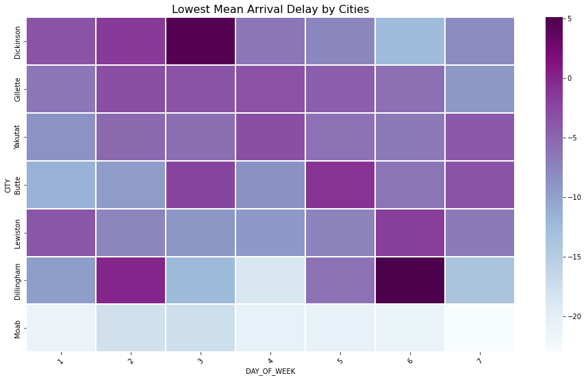

```python
arr = df.pivot_table(index="CITY_x",columns="DAY_OF_WEEK",values="ARRIVAL_DELAY",
                     aggfunc=lambda x:x.mean())
arr['sum'] = arr[1] + arr[2] +arr[3]+arr[4]+arr[5]+arr[6]+arr[7]

fv = arr.sort_values(by='sum')[:7]
fv = fv.iloc[::-1]
fv = fv.drop(['sum'], axis=1)
fig = plt.figure(figsize=(16,9))
sns.heatmap(fv, cmap='BuPu',linecolor="w", linewidths=2)

plt.title('Lowest Mean Arrival Delay by Cities', size=16)
plt.ylabel('CITY')
plt.xticks(rotation=45)
plt.show()
```

```python
arr = df.pivot_table(index="CITY_x",columns="DAY_OF_WEEK",values="ARRIVAL_DELAY",
                     aggfunc=lambda x:x.mean())
arr['sum'] = arr[1] + arr[2] +arr[3]+arr[4]+arr[5]+arr[6]+arr[7]
fv = arr.sort_values(by='sum')[:8]
fv = fv.iloc[::-1]
fv = fv.drop(['sum'], axis=1)

trace = go.Heatmap(z=[fv.values[1],fv.values[2],fv.values[3],fv.values[4],fv.values[5],
                      fv.values[6],fv.values[7]],
                   x=['Monday', 'Tuesday', 'Wednesday', 'Thursday', 'Friday','Saturday','Sunday'],
                   y=fv.index.values, colorscale='Blues',
                   reversescale = True
                  )

data=[trace]
layout = go.Layout(
    title='Lowest Arrival Delay by Cities')

fig = go.Figure(data=data, layout=layout)
py.iplot(fig)
```

[interactive chart not shown]

## 2. Taxi Out vs. Taxi In

#### Reminder:

- taxi_out = wheels_off - departure_time
- taxi_in = arrival_time - wheels_on

```python
dff = df.groupby('AIRLINE').TAXI_OUT.mean().to_frame().sort_values(by='TAXI_OUT',
                                                    ascending=False)[:8].round(2)

trace1 = go.Bar(
    x=dff.index,
    y=dff.TAXI_OUT,name='TAXI_OUT',
    marker=dict(
        color = 'aqua'
    )
)

dff = df.groupby('AIRLINE').TAXI_IN.mean().to_frame().sort_values(by='TAXI_IN',
                                                        ascending=False)[:8].round(2)

trace2 = go.Bar(
    x=dff.index,
    y=dff.TAXI_IN, name='TAXI_IN',
    marker=dict(
       color = 'indigo'
    )
)

fig = tools.make_subplots(rows=1, cols=2, subplot_titles=('Median Taxi Out', 'Median Taxi In'))

fig.append_trace(trace1, 1,1)
fig.append_trace(trace2, 1,2)

fig['layout'].update(yaxis = dict(title = 'minute'), height=500, width=850,
                     title='Which is hard whell-off or whell-on?',
                     showlegend=False)
py.iplot(fig)
```

[interactive chart not shown]

**Newton's theory of gravitation :)**

```python
df['OUT_IN_DIFF'] = df['TAXI_OUT'] - df['TAXI_IN']
dff = df.groupby('AIRLINE').OUT_IN_DIFF.mean().to_frame().sort_values(by='OUT_IN_DIFF',
                                                    ascending=False).round(2)

trace = go.Bar(
    x=dff.index,
    y=dff.OUT_IN_DIFF,
    marker=dict(
        color = dff.OUT_IN_DIFF,
        colorscale='Jet',
        showscale=True
    )
)

data = [trace]
layout = go.Layout(xaxis=dict(tickangle=15),
    title='Mean (Taxi Out - Taxi In) by Airlines',
                   yaxis = dict(title = 'minute'
                                                               )
)

fig = go.Figure(data=data, layout=layout)
py.iplot(fig)
```

[interactive chart not shown]

### 3. Speed

```python
df['SPEED'] = 60*df['DISTANCE']/df['AIR_TIME']
dff = df.groupby('AIRLINE').SPEED.mean().to_frame().sort_values(by='SPEED',
                                                    ascending=False).round(2)

trace = go.Scatter(
    x=dff.index,
    y=dff.SPEED,
    mode='markers',
    marker=dict(
        sizemode = 'diameter',
        sizeref = 1,
        size = 30,
        color = dff.SPEED.values,
        colorscale='Jet',
        showscale=True
    )
)

data = [trace]
layout = go.Layout(xaxis=dict(tickangle=-20),
    title='Mean Speed by Airlines',
                   yaxis = dict(title = 'Speed')
)

fig = go.Figure(data=data, layout=layout)
py.iplot(fig)
```

[interactive chart not shown]

### 4. Cancellation Rates

```python
dff = df.groupby('AIRLINE')[['CANCELLED']].mean().sort_values(by='CANCELLED',
                                                    ascending=False).round(3)

trace1 = go.Scatter(
    x=dff.index,
    y=dff.CANCELLED,
    mode='markers',
    marker=dict(
        symbol = 'star-square',
        sizemode = 'diameter',
        sizeref = 1,
        size = 30,
        color = dff.CANCELLED,
        colorscale='Portland',
        showscale=True
    )
)

data = [trace1]
layout = go.Layout(xaxis=dict(tickangle=20),
    title='Cancellation Rate by Airlines', yaxis = dict(title = 'Cancellation Rate'
                                                       )
)

fig = go.Figure(data=data, layout=layout)
py.iplot(fig, filename="age")

dff = df.groupby('CITY_x')[['CANCELLED']].mean().sort_values(by='CANCELLED',
                                            ascending=False)[:10].round(3)
trace2 = go.Scatter(
    x=dff.index,
    y=dff.CANCELLED,
    mode='markers',
    marker=dict(symbol = 'diamond',
        sizemode = 'diameter',
        sizeref = 1,
        size = 30,
        color = dff.CANCELLED,
        colorscale='Portland',
        showscale=True
    )
)

data = [trace2]
layout = go.Layout(xaxis=dict(tickangle=20),
    title='Cancellation Rate by Cities',
                   yaxis = dict(title = 'Cancellation Rate'
                                                     )
)

fig = go.Figure(data=data, layout=layout)
py.iplot(fig)
```

[interactive chart not shown]

### 5. Cancellation Reasons

*Do you wonder why flights are cancelled wheather, security or anything else?*

```python
reason={'A':'Airline/Carrier', 'B':'Weather', 'C':'National Air System', 'D':'Security'}
df.CANCELLATION_REASON = df.CANCELLATION_REASON.map(reason)

dff = df[df.CANCELLED==1]['MONTH'].value_counts().reset_index().sort_values(by='index')
dff.columns = ['month', 'flight_num']
dff.month = dff.month.map(month)

trace = go.Bar(
    x=dff.month,
    y=dff.flight_num,
    marker=dict(
        color = dff.flight_num,
        colorscale='Reds',
        showscale=True
    )
)

data = [trace]
layout = go.Layout(
    title='# of Cancelled Flights (monthly)',
    yaxis = dict(title = '# of Flights'
                                                          )
)

fig = go.Figure(data=data, layout=layout)
py.iplot(fig)
```

[interactive chart not shown]

**Cancelation rate rises dramatically in Dec-Jan-Feb. Is it all about weather?**

```python
dff = df[df.CANCELLATION_REASON=='Weather'].MONTH.value_counts()
dff = dff.to_frame().sort_index()
dff.index = dff.index.map(month)

trace1 = go.Bar(
    x=dff.index,
    y=dff.MONTH,
    name = 'Weather',
    marker=dict(
        color = 'aqua'
    )
)

dff = df[df.CANCELLATION_REASON=='Airline/Carrier'].MONTH.value_counts()
dff = dff.to_frame().sort_index()
dff.index = dff.index.map(month)

trace2 = go.Bar(
    x=dff.index,
    y=dff.MONTH,
    name='Airline/Carrier',
    marker=dict(
        color = 'red'
    )
)

dff = df[df.CANCELLATION_REASON=='National Air System'].MONTH.value_counts()
dff = dff.to_frame().sort_index()
dff.index = dff.index.map(month)

trace3 = go.Bar(
    x=dff.index,
    y=dff.MONTH,
    name='National Air System',
    marker=dict(
        color = 'navy'
    )
)

data = [trace1,trace2,trace3]
layout = go.Layout(
    title='Cancellation Reasons (Monthly)',
    yaxis = dict(title = '# of Flights'
                                                        )
)

fig = go.Figure(data=data, layout=layout)
py.iplot(fig)
```

[interactive chart not shown]

**Weather seems the major cause of cancellations especially in the winter.**

**Do you think that there is a relation between day of week & cancellation rate? Probably not?**

```python
dff = df[df.CANCELLATION_REASON == 'Weather'].DAY_OF_WEEK.value_counts()
dff = dff.to_frame().sort_index()
dff.index = dff.index.map(dayOfWeek)

trace1 = go.Bar(
    x=dff.index,
    y=dff.DAY_OF_WEEK,
    name = 'Weather',
    marker=dict(
        color = 'aqua'
    )
)

dff = df[df.CANCELLATION_REASON=='Airline/Carrier'].DAY_OF_WEEK.value_counts()
dff = dff.to_frame().sort_index()
dff.index = dff.index.map(dayOfWeek)

trace2 = go.Bar(
    x=dff.index,
    y=dff.DAY_OF_WEEK,
    name='Airline/Carrier',
    marker=dict(
        color = 'red'
    )
)

dff = df[df.CANCELLATION_REASON=='National Air System'].DAY_OF_WEEK.value_counts()
dff = dff.to_frame().sort_index()
dff.index = dff.index.map(dayOfWeek)

trace3 = go.Bar(
    x=dff.index,
    y=dff.DAY_OF_WEEK,
    name='National Air System',
    marker=dict(
        color = 'navy'
    )
)

data = [trace1,trace2,trace3]
layout = go.Layout(
    title='Cancellation Reasons (Day of Week)',
    yaxis = dict(title = '# of Flights'
                                                            )
)

fig = go.Figure(data=data, layout=layout)
py.iplot(fig)
```

[interactive chart not shown]

```python
df['Date'] = pd.to_datetime(df[['DAY','MONTH','YEAR']])
df = df[df.MONTH < 9]
df1dm = df.resample('D', on='Date').mean()
df1wm = df.resample('W', on='Date').mean()
df1mm = df.resample('M', on='Date').mean()
df1dc = df.resample('D', on='Date').count()
df1wc = df.resample('W', on='Date').count()
df1mc = df.resample('M', on='Date').count()
```

```python
hist_data = [df1dm[df1dm.DAY_OF_WEEK<6].ARRIVAL_DELAY, df1dm[df1dm.DAY_OF_WEEK==6].ARRIVAL_DELAY,
            df1dm[df1dm.DAY_OF_WEEK==7].ARRIVAL_DELAY]

labels = ['Weekday', 'Saturday','Sunday']
colors = ['navy', 'green', 'red']

fig = ff.create_distplot(hist_data, labels, colors=colors,
                         show_hist=False, bin_size=.2)

fig['layout'].update(title='Mean Arrival Delay')
py.iplot(fig)
```

[interactive chart not shown]

```python
correlation = df[['DAY_OF_WEEK','MONTH','ELAPSED_TIME', 'AIR_TIME', 'DISTANCE',
       'WHEELS_ON', 'TAXI_IN', 'SCHEDULED_ARRIVAL', 'ARRIVAL_TIME',
       'ARRIVAL_DELAY','SPEED']].fillna(0).corr()
cols = correlation.columns.values
corr  = correlation.values

trace = go.Heatmap(z = corr,
                   x = cols,
                   y = cols,
                   colorscale = "YlOrRd",reversescale = True
                                    )

data = [trace]
layout = go.Layout(dict(title = "Correlation Matrix for variables",
                        autosize = False,
                        height  = 600,
                        width   = 800,
                        margin  = dict(l = 200
                                      ),
                        yaxis   = dict(tickfont = dict(size = 8)),
                        xaxis   = dict(tickfont = dict(size = 8))
                       )
                  )

fig = go.Figure(data=data,layout=layout)
py.iplot(fig)
```

[interactive chart not shown]

**Your feedback really matters - please share your thoughts and suggestions.**